# Tarea 6 Inferencia Estadística

Hairo Ulises Miranda Belmonte

26 de Noviembre de 2018

## EJERCICIO 1

Se realizaran 1000 simulaciones, asumiendo los valores de las variables y las muestras.

```r
B<- 1000 # simulaciones
x1 <- 40
n1 <- 50
x2 <- 30
n2 <- 50
```

Dado que bajo la posterior, tanto p1 como p2 son independientes, entonces para obtener la distribución de la posterior realizamos obtenemos B observaciones de la posterior, en este caso de cda p1 y p2

```r
# muestra de las posterior
p1 <- rbeta(B, x1+1, n1-x1+1)
p2 <- rbeta(B, x2+1, n2-x2+1)
```

observamos como la media de p1 y p2 bajo la posteror se aproximan a la media estimada por verosiilitud

```r
# media de maxima verosimilitud aproximada a postrior
postmean<-mean(p1)
meanML <-x1/n1
cat("Media posteriori P1", postmean, "\n")
```

```
## Media posteriori P1 0.7876267
```

```r
cat("Estadístico de máxima Verosimilitud de P1", meanML, "\n")
```

```
## Estadístico de máxima Verosimilitud de P1 0.8
```

```r
postmean2<-mean(p2)
meanML2 <-x2/n2
cat("Media posteriori P2", postmean2, "\n")
```

```
## Media posteriori P2 0.5974246
```

```r
cat("Estadístico de máxima Verosimilitud de P2", meanML2, "\n")
```

```
## Estadístico de máxima Verosimilitud de P2 0.6
```

Realizamos la transformacion de la variable y observamos la media posterior de la función, y obtenemos su densidad al reaizar el histograma

```r
# realizando la transformacion de la variable
tau <- p1-p2
meantau <- mean(tau)
cat("Media posteriori de la transformación", mean(tau), "\n")
```

```
## Media posteriori de la transformación 0.1902021
```

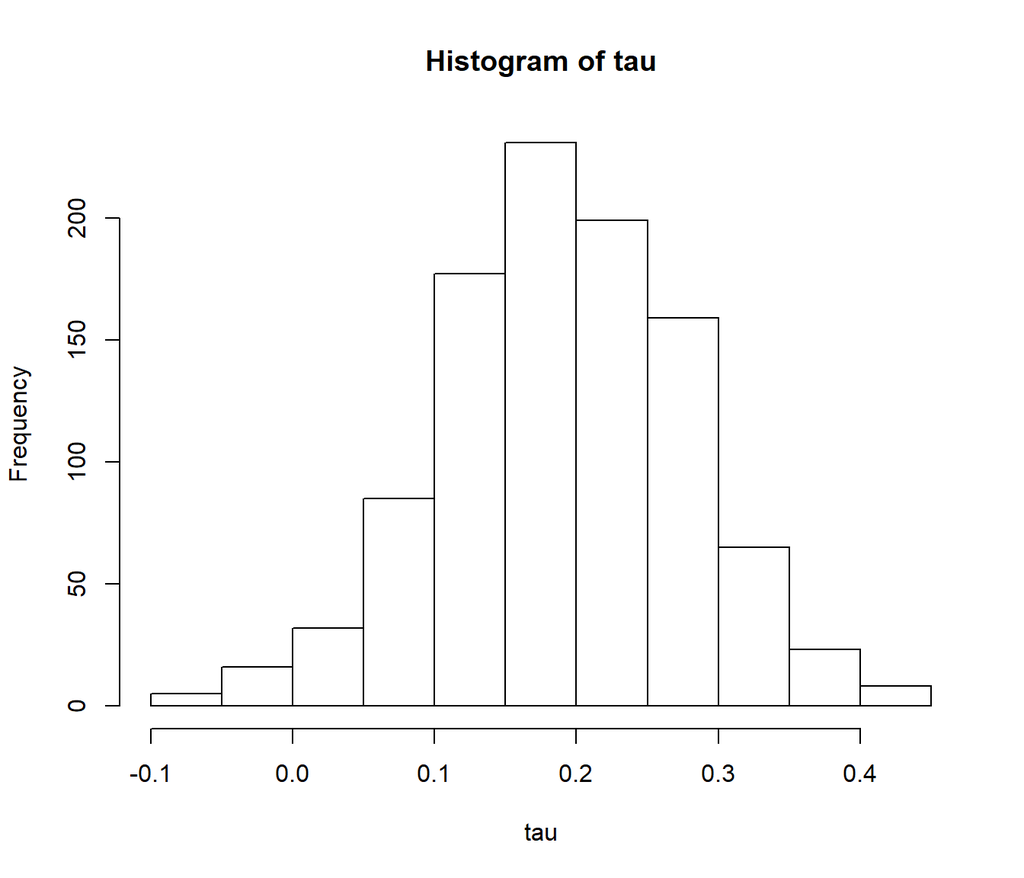

```r
hist(tau)
```

Se puede observar la densidad de la trasformación o más bien, la posterior de tau.

## EJERCICIO 2

2. Sean X1, . . . , Xn Normal(µ, 1)
1. Simule un conjunto de datos (use µ = 5) de n = 100 observaciones. Generar sample con media de cinco.

```r
x <- rnorm(100,5,1)
mu <- 5
prior <- 1
```

2. Tome f(µ) = 1 y halle la densidad posteriori. Grafique la densidad. La posteriror es una normal con media del estimador de máxima verosimilitud Con base al sample generamos las observaciones de la posterior.

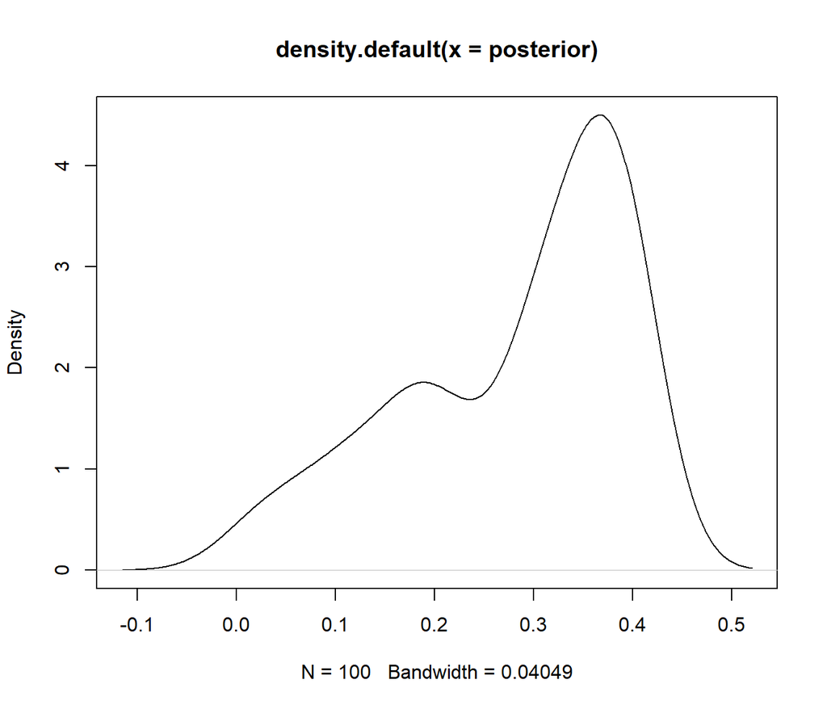

```r
posterior <- dnorm(x,mean(x),1)
plot(density(posterior))
```

Como se puede observar , no se distribuye como una normal . Sin embargo, necesitamos varias observaciones para que esto suceda.

3. Simule 1000 observaciones de la posteriori. Grafique un histograma y compare con la densidad del punto anterior.

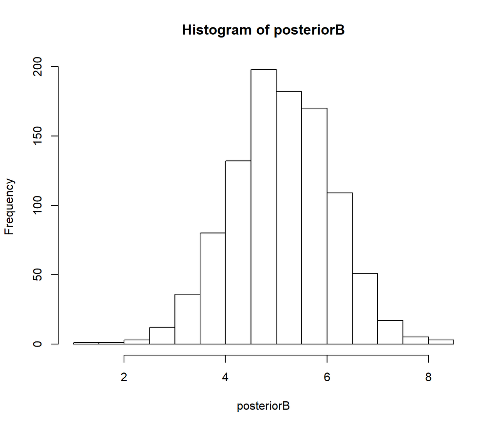

```r
# 1000 simulaciones de la posterior}

posteriorB <-replicate(1000,rnorm(1,mean(x),1))
hist(posteriorB)
```

```r
meanpost<- mean(posteriorB)
cat("Media posteriori ", meanpost, "\n")
```

```
## Media posteriori  5.101425
```

```r
# al realizar mil observaciones de una posterior y utilizar el histograma, ya parece normal
```

Podemos observar que la posterior al realizar varias simulaciones y tomar su media, se aproxima a la media del estadístico de la verosimilitud de unna normal.

Realizamos una transformación

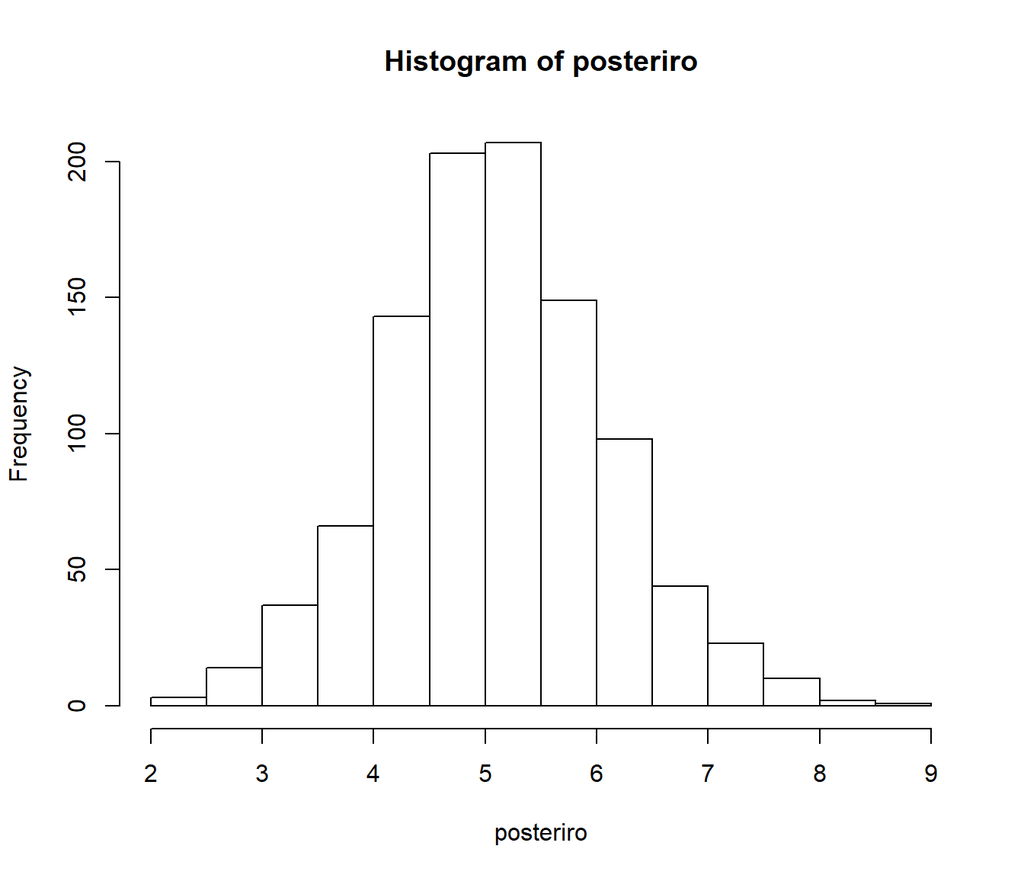

```r
posteriro <- rnorm(B, mean(x),1)
hist(posteriro)
```

```r
mediapos<-mean(posteriro)
cat("Media posteriori ", mediapos, "\n")
```

```
## Media posteriori  5.099245
```

construimos intervalos de confianza posteriori

```r
IC <- c(quantile(posteriro,.05/2),
cat("Intervalos de confianza posteriori ", quantile(posteriro,1-.05/2)), "\n")
```

```
## Intervalos de confianza posteriori  7.094697
```

En base a conocer la distribución de la transformación, las B observaciones generadas por la posterior, se evaluand en la transformacion.

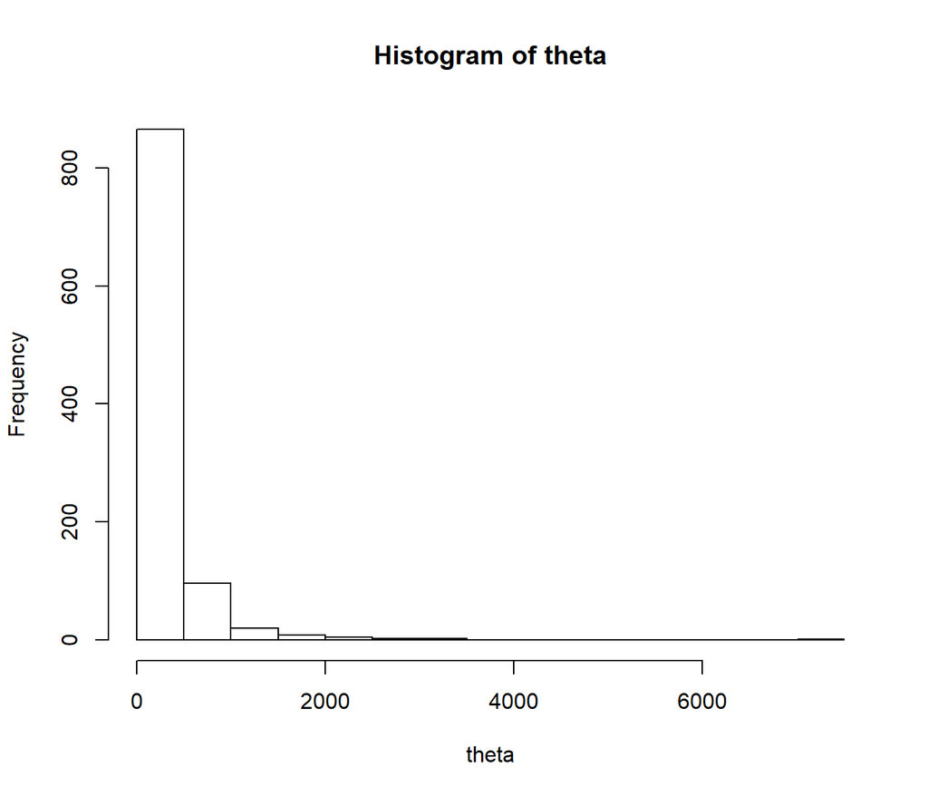

```r
theta <- exp(posteriro)
hist(theta)
```

```r
media<-mean(theta)
cat("Media posterior transformación ", media, "\n")
```

```
## Media posterior transformación  275.7255
```

Se pued eobservar que la función se comporta como una exponencial. Realizamos su intervalo posteriori a la transformación

```r
ICPosterior <- c(quantile(theta,.05/2), quantile(theta,1-.05/2))
cat("Intervalos de confianza posteriori ", quantile(theta,1-.05/2), "\n")
```

```
## Intervalos de confianza posteriori  1205.59
```

```r
z <- qnorm(1-.05/2)
ICNormal<- c(mean(theta)-z, mean(theta)+z)
cat("Intervalos de confianza normal ", quantile(theta,1-.05/2), "\n")
```

```
## Intervalos de confianza normal  1205.59
```